# SNAI2

Lucio Rodriguez

2018-08-06

```r
library(limma)
library(edgeR)
library(Glimma)
library(gplots)
library(RColorBrewer)
library(readxl)
library(CAMERA)
```

# 1. DATA

Los datos que vamos a estudiar provienen de *GEO (GSE77940)*. Tenemos seis pacientes de melanoma con sus ARN expresión antes y después de suministrarles un tratamiento con inhibidores RAF o RAF+MEK.

La proteína *SNAI2* es un inhibidor de la transcripción implicada en funciones antiapoptóticas. El objetivo de este estudio es poder demostrar si la proteína *SNAI2* aumenta cuando se le administra a un paciente inhibidores como *Trametinib*.

Leemos los datos y creamos nuestra matriz de recuentos y nuestra tabla “sampleinfo” (con información extra).

```r
library(readxl)
GSE77940_pre_post_melanoma <- read_excel("C:/Users/lrodriguez/Desktop/VHIO/ARNseq/SNAI2/GSE77940_pre_post_melanoma.xlsx")
seqdata<-GSE77940_pre_post_melanoma
x<-c("pre", "post","pre", "post","pre", "post","pre", "post","pre", "post","pre", "post")
sampleinfo<-as.data.frame(x)
rownames(sampleinfo)<-colnames(seqdata[,3:14])
colnames(sampleinfo)<-"treatement"
#remove(GSE77940_pre_post_melanoma)
```

```r
#######
countdata<-seqdata
countdata<-countdata[,-(1:2)]
#Eliminamos duplicated genes
duplicated<-which(duplicated(seqdata$`Gene Symbol`))
seqdata<-seqdata[-duplicated,]
countdata<-countdata[-duplicated,]
#Ponemos como rownames en el countdata los nombres de los genes
rownames(countdata)<-seqdata$`Gene Symbol`
```

# 2. Filtering and remove lowly expressed genes

Los genes con recuentos muy bajos en todas las bibliotecas proporcionan poca evidencia en la expresión diferencial e interfieren con algunas de las aproximaciones estadísticas que se utilizan más adelante dentro del pipeleine del análisis. Asimismo añaden “ruido”" en el ajuste por múltiple testing mediante FDR, reduciendo “potencia estadística” en la detección de genes expresados diferencialmente.

Hay diferentes maneras de filtrar genes poco expresados. En este caso optamos por retener los genes si se expresan en un conteo por millón (CPM) por encima de 0.5 en al menos dos muestras. Utilizaremos la función cpm del package edgeR para generar los valores de CPM (conteo por millón) y luego filtrar. Hay que tener presente que al convertir a CPM estamos normalizando segun el “Sequencing depth” (número de lecturas) de cada muestra.

```r
#4 Filtering and remove lowly expressed genes
# Obtain CPMs
myCPM <- cpm(countdata)
# Have a look at the output
head(myCPM)
```

```
##            Patient1_Pre Patient1_Post Patient2_Pre Patient2_Post
## DDX11L1       0.3139968     0.2093069      0.00000    0.06959126
## WASH7P       30.8324554    33.2853724     48.74618   33.42799719
## MIR1302-11    0.0000000     0.0000000      0.00000    0.00000000
## FAM138A       0.0000000     0.1291212      0.00000    0.00000000
## OR4G11P       0.0000000     0.0000000      0.00000    0.00000000
## OR4F5         0.0000000     0.0000000      0.00000    0.00000000
##            Patient3_Pre Patient3_Post Patient4_Pre- Patient4_Post
## DDX11L1         0.00000      0.000000       0.00000    0.00000000
## WASH7P         19.34072     41.872042      32.05512   28.98164363
## MIR1302-11      0.00000      1.344142       0.00000    0.00000000
## FAM138A         0.00000      0.000000       0.00000    0.07801432
## OR4G11P         0.00000      0.000000       0.00000    0.00000000
## OR4F5           0.00000      0.000000       0.00000    0.00000000
##            Patient5_Pre Patient5_Post Patient6_Pre Patient6_Post
## DDX11L1       0.1044497        0.0000      0.00000     0.1120332
## WASH7P       18.4476486       21.0217     20.25412    22.8255585
## MIR1302-11    0.0000000        0.0000      0.00000     0.0000000
## FAM138A       0.0000000        0.0000      0.00000     0.1036698
## OR4G11P       0.0000000        0.0000      0.00000     0.0000000
## OR4F5         0.0000000        0.0000      0.00000     0.0000000
```

```r
# Which values in myCPM are greater than 0.5?
thresh <- myCPM > 0.5
# This produces a logical matrix with TRUEs and FALSEs
head(thresh)
```

```
##            Patient1_Pre Patient1_Post Patient2_Pre Patient2_Post
## DDX11L1           FALSE         FALSE        FALSE         FALSE
## WASH7P             TRUE          TRUE         TRUE          TRUE
## MIR1302-11        FALSE         FALSE        FALSE         FALSE
## FAM138A           FALSE         FALSE        FALSE         FALSE
## OR4G11P           FALSE         FALSE        FALSE         FALSE
## OR4F5             FALSE         FALSE        FALSE         FALSE
##            Patient3_Pre Patient3_Post Patient4_Pre- Patient4_Post
## DDX11L1           FALSE         FALSE         FALSE         FALSE
## WASH7P             TRUE          TRUE          TRUE          TRUE
## MIR1302-11        FALSE          TRUE         FALSE         FALSE
## FAM138A           FALSE         FALSE         FALSE         FALSE
## OR4G11P           FALSE         FALSE         FALSE         FALSE
## OR4F5             FALSE         FALSE         FALSE         FALSE
##            Patient5_Pre Patient5_Post Patient6_Pre Patient6_Post
## DDX11L1           FALSE         FALSE        FALSE         FALSE
## WASH7P             TRUE          TRUE         TRUE          TRUE
## MIR1302-11        FALSE         FALSE        FALSE         FALSE
## FAM138A           FALSE         FALSE        FALSE         FALSE
## OR4G11P           FALSE         FALSE        FALSE         FALSE
## OR4F5             FALSE         FALSE        FALSE         FALSE
```

```r
# Summary of how many TRUEs there are in each row
# There are 13500 genes that have TRUEs in all 12 samples.

table(rowSums(thresh))
```

```
##
##     0     1     2     3     4     5     6     7     8     9    10    11
## 22832  3162  1679  1178   886   731   697   653   636   648   824  1216
##    12
## 13500
```

```r
# we would like to keep genes that have at least 2 TRUES in each row of thresh
keep <- rowSums(thresh) >= 2
# Subset the rows of countdata to keep the more highly expressed genes
counts.keep <- countdata[keep,]
seqdata1<-seqdata[keep,]
rownames(seqdata1)<-seqdata1$`Gene Symbol`
rownames(counts.keep)<-rownames(seqdata1)
summary(keep)
```

```
##    Mode   FALSE    TRUE
## logical   25994   22648
```

```r
dim(counts.keep)
```

```
## [1] 22648    12
```

# 3. Counts to DGEList object

Convertimos nuestra matriz de datos a un DGEList.

```r
y <- DGEList(counts.keep)
# have a look at y
y$counts[1:5,1:5]
```

```
##               Patient1_Pre Patient1_Post Patient2_Pre Patient2_Post
## WASH7P          14.3381119    13.8224640   20.1737690    12.7033663
## RP11-34P13.7     0.7074306     0.4840285    0.4439442     0.3092701
## RP11-34P13.8     0.8429023     0.7681044    0.7002667     0.3957906
## RP11-34P13.11    4.3387656     2.3344004    1.7570927     2.0587924
## RP11-34P13.14    0.6374201     0.8600422    0.3237286     0.6926773
##               Patient3_Pre
## WASH7P           8.0845423
## RP11-34P13.7     0.2363013
## RP11-34P13.8     0.3485384
## RP11-34P13.11    1.1136495
## RP11-34P13.14    0.7116442
```

# 4. Quality control

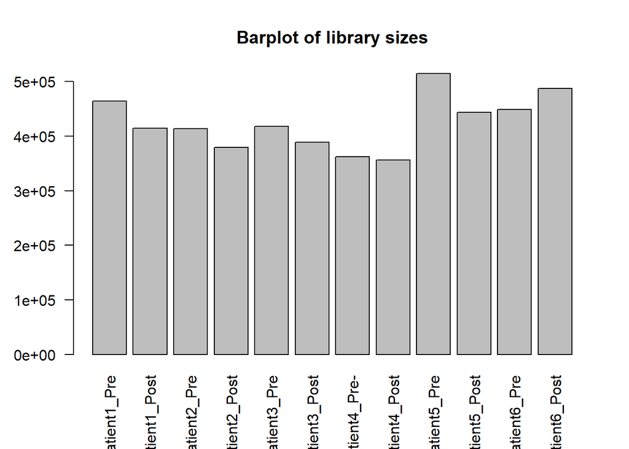

```r
# The names argument tells the barplot to use the sample names on the x-axis
# The last argument rotates the axis names
barplot(y$samples$lib.size,names=colnames(y),las=2)
# Add a title to the plot
title("Barplot of library sizes")
```

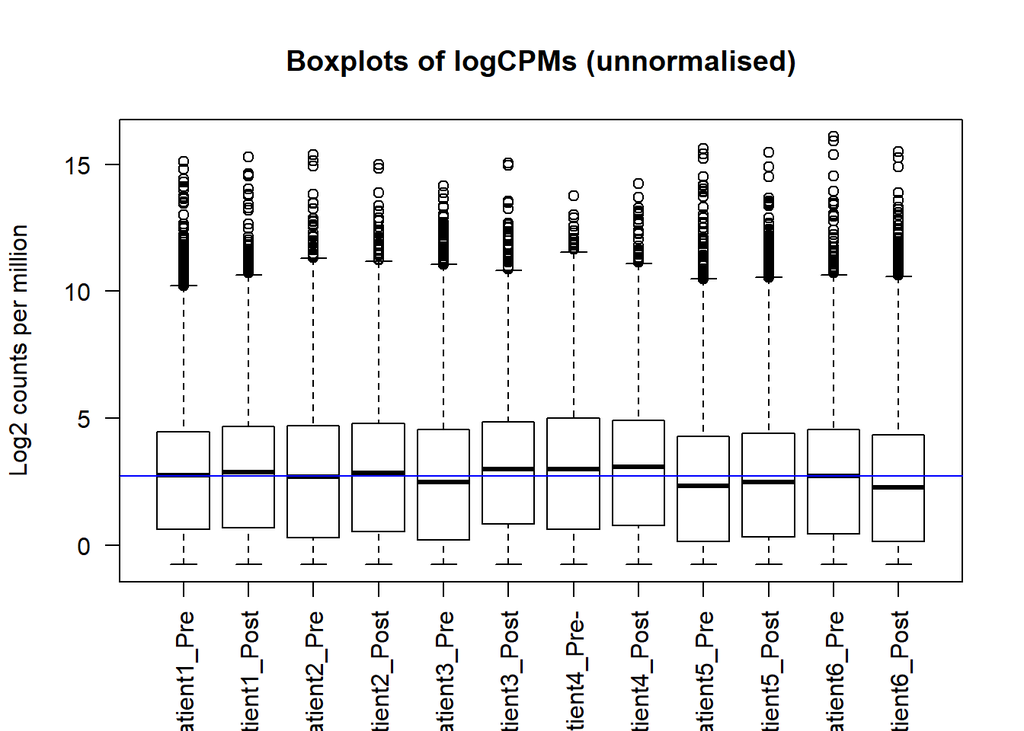

```r
# Get log2 counts per million
logcounts <- cpm(y,log=TRUE)
# Check distributions of samples using boxplots
boxplot(logcounts, xlab="", ylab="Log2 counts per million",las=2)
# Let's add a blue horizontal line that corresponds to the median logCPM
abline(h=median(logcounts),col="blue")
title("Boxplots of logCPMs (unnormalised)")
```

# 4.1 Multidimensional scaling plots

Un MDSplot es un gráfico, que nos permite “visualizar” variabilidad en los datos. Si su experimento está bien “controlado”" y funcionó bien, lo que esperamos ver es que las principales fuentes de variación en los datos sean los tratamientos / grupos que nos interesan.

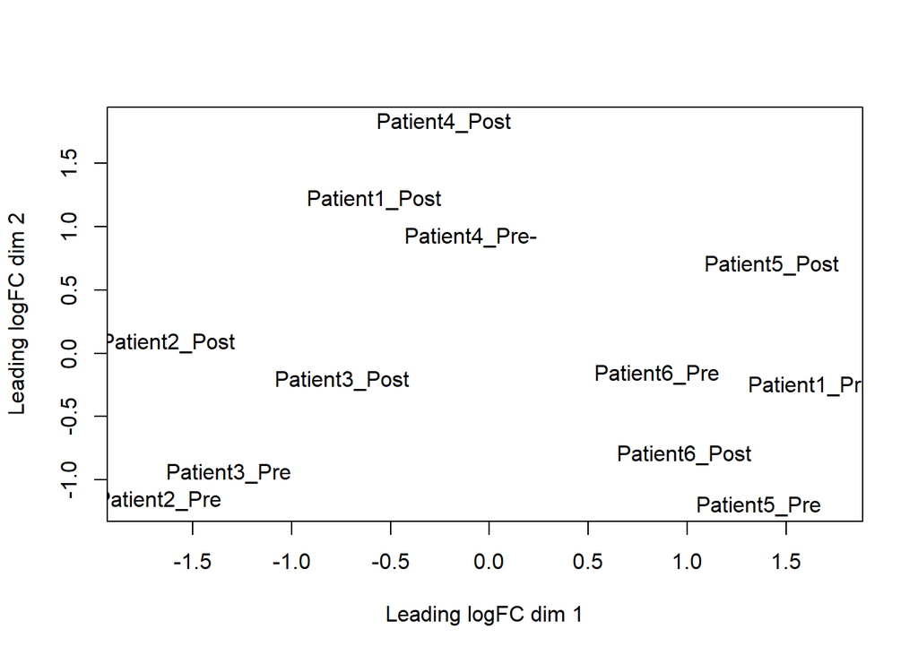

```r
plotMDS(y)
```

```r
levels(sampleinfo$treatement)
```

```
## [1] "post" "pre"
```

```r
col.cell <- c("purple","orange")[sampleinfo$treatement]
data.frame(sampleinfo$treatement,col.cell)
```

```
##    sampleinfo.treatement col.cell
## 1                    pre   orange
## 2                   post   purple
## 3                    pre   orange
## 4                   post   purple
## 5                    pre   orange
## 6                   post   purple
## 7                    pre   orange
## 8                   post   purple
## 9                    pre   orange
## 10                  post   purple
## 11                   pre   orange
## 12                  post   purple
```

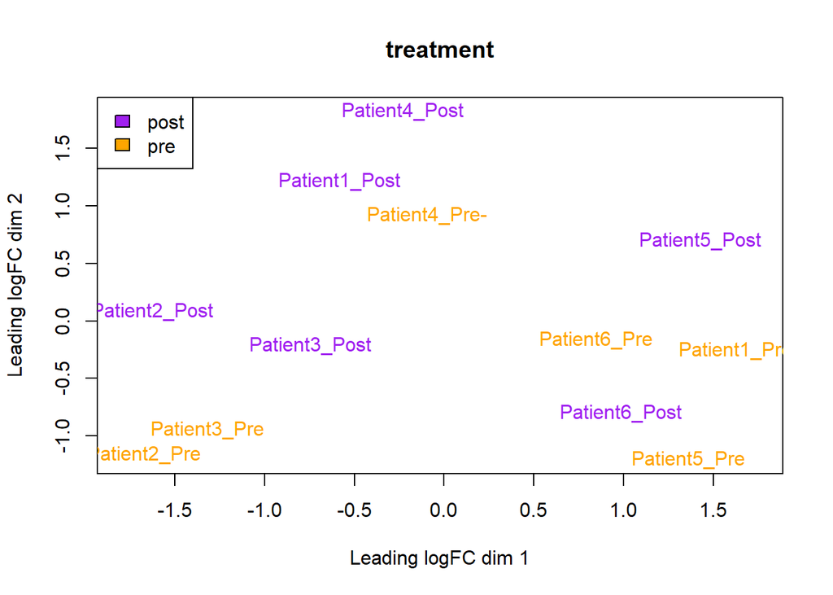

```r
# Redo the MDS with cell type colouring
plotMDS(y,col=col.cell)
# Let's add a legend to the plot so we know which colours correspond to which cell type
legend("topleft",fill=c("purple","orange"),legend=levels(sampleinfo$treatement))
# Add a title
title("treatment")
```

```r
#################
labels <- paste(sampleinfo$treatement)
group <- paste(sampleinfo$treatement,sampleinfo$Status,sep=".")
group <- factor(group)
glMDSPlot(y, labels=labels, groups=group, folder="mds")
```

El MDS también nos puede aportar información sobre posibles **efectos batch** (potential batch effects) lo que conllevaria “a tener lo en cuenta en la matriz de diseño” previo a la obtención de la expresión diferencial, que veremos más adelante. Por ejemplo, suponed que la primera réplica de cada grupo se hubiera preparado y realizaddo en un momento diferente de la segunda réplica. Si el MDS hubiera “reflejado” dicha separación de las muestras por tiempo, podría valer la pena incluir el “factor tiempo en el análisis” como efecto batch.

# 4.2 Hierarchical clustering with heatmaps

```r
# We estimate the variance for each row in the logcounts matrix
var_genes <- apply(logcounts, 1, var)
head(var_genes)
```

```
##        WASH7P  RP11-34P13.7  RP11-34P13.8 RP11-34P13.11 RP11-34P13.14
##     0.1999373     0.2055349     0.2676324     0.5181461     0.4748035
## RP11-34P13.12
##     0.0980100
```

```r
# Get the gene names for the top 500 most variable genes
select_var <- names(sort(var_genes, decreasing=TRUE))[1:500]
head(select_var)
```

```
## [1] "FDCSP"  "GAGE2D" "GAGE2A" "PAGE5"  "GAGE2C" "NTS"
```

```r
# Subset logcounts matrix
highly_variable_lcpm <- logcounts[select_var,]
dim(highly_variable_lcpm)
```

```
## [1] 500  12
```

```r
head(highly_variable_lcpm)
```

```
##        Patient1_Pre Patient1_Post Patient2_Pre Patient2_Post Patient3_Pre
## FDCSP    2.90335312     1.6311656    1.2488653     0.9322499    1.0933828
## GAGE2D   1.20434920     8.5967402    0.1091397     1.9474584    6.1979360
## GAGE2A   1.28482218     8.7475407    0.1993932     1.5340700    3.4120390
## PAGE5    0.09325244     7.3288198    9.0111526     8.3099750   -0.3888221
## GAGE2C  -0.76250045     7.1404387   -0.2618300     0.6574697    3.4572907
## NTS     -0.76250045     0.1996985    9.6073840    10.9396985    5.4120218
##        Patient3_Post Patient4_Pre- Patient4_Post Patient5_Pre
## FDCSP      2.0895643     1.0224621   11.62977613   4.70887199
## GAGE2D     2.1470413     9.9025553    9.74404386   0.06412825
## GAGE2A     0.8365282     8.5282359    8.79139150  -0.11351459
## PAGE5      1.5039574    -0.5041081   -0.03726013   1.38523946
## GAGE2C     1.0517192     7.7399793    7.94411420  -0.50744208
## NTS        3.3725326     0.5056517    0.97961208   0.18915234
##        Patient5_Post Patient6_Pre Patient6_Post
## FDCSP       8.021467   11.2492178   10.47151949
## GAGE2D      3.163257   10.2069762   10.73871276
## GAGE2A      3.064964    9.4926004   10.24617684
## PAGE5       1.972016    7.7855732    8.58535197
## GAGE2C      2.199138    8.6079310    9.50089973
## NTS         1.773049    0.4649221    0.08120239
```

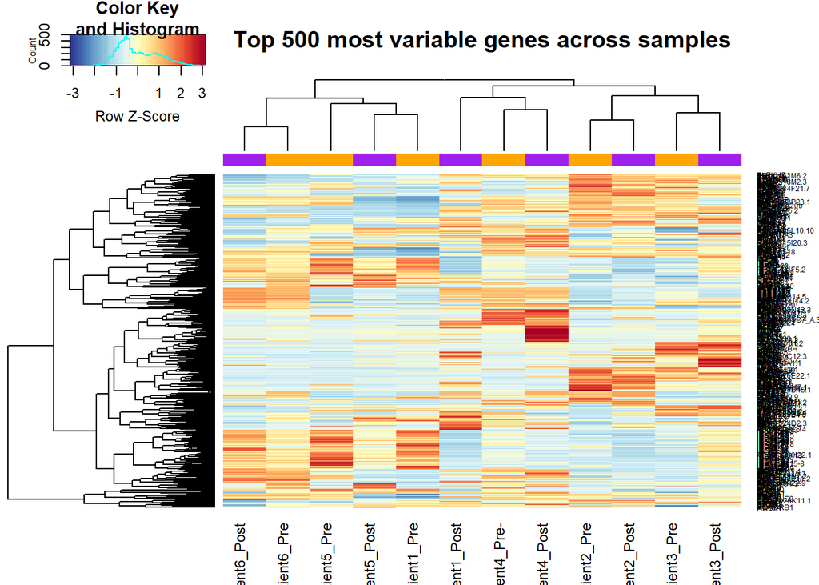

```r
## Get some nicer colours
mypalette <- brewer.pal(11,"RdYlBu")
morecols <- colorRampPalette(mypalette)
# Set up colour vector for celltype variable
col.cell <- c("purple","orange")[sampleinfo$treatement]

# Plot the heatmap
heatmap.2(highly_variable_lcpm,col=rev(morecols(50)),trace="none", main="Top 500 most variable genes across samples",ColSideColors=col.cell,scale="row")
```

# 5. Normalisation for “composition bias”

```r
# Apply normalisation to DGEList object
y <- calcNormFactors(y)
#y$samples
levels(group)
```

```
## [1] "post." "pre."
```

```r
design <- model.matrix(~ 0 + group)
colnames(design)<-levels(group)
```

Podemos normalizar los datos de diferentes maneras.

- **1. Total read count normalization**

**cpm(…, normalized.lib.sizes = TRUE){edgeR}**

- **2. Upper quartile normalization.**

**calcNormFactors(…, method = “upperquartile”, p = 0.75){edgeR}**

- **3. Relative Log Expression (RLE)**

**calcNormFactors(…, method = “RLE”){edgeR}** **estimateSizeFactors(…){DESeq, DESeq2}**

# 6. VOOM

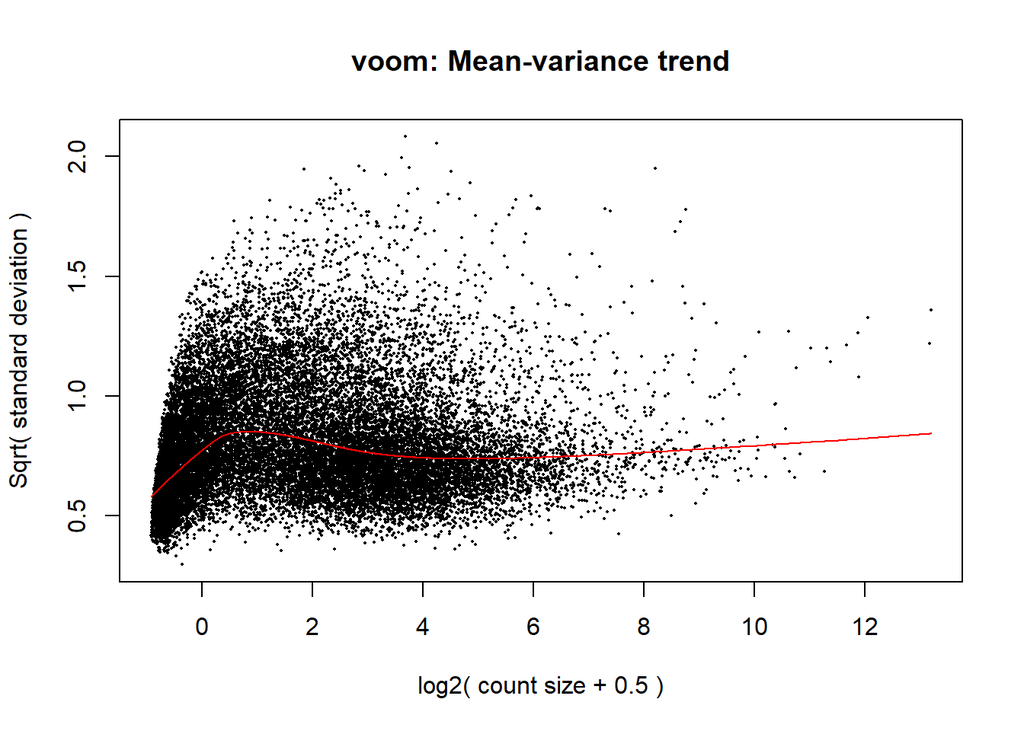

```r
v <- voom(y,design,plot = TRUE)
```

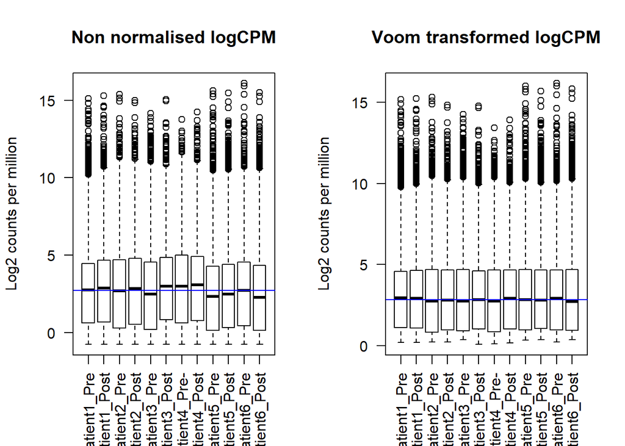

```r
###################################
par(mfrow=c(1,2))
boxplot(logcounts, xlab="", ylab="Log2 counts per million",las=2,main="Non normalised logCPM")
## Let's add a blue horizontal line that corresponds to the median logCPM
abline(h=median(logcounts),col="blue")
boxplot(v$E, xlab="", ylab="Log2 counts per million",las=2,main="Voom transformed logCPM")
## Let's add a blue horizontal line that corresponds to the median logCPM
abline(h=median(v$E),col="blue")
```

# 9 Testing for differential expression

```r
cont.matrix <- makeContrasts(postvspre=post. - pre.,levels=design)
cont.matrix
```

```
##        Contrasts
## Levels  postvspre
##   post.         1
##   pre.         -1
```

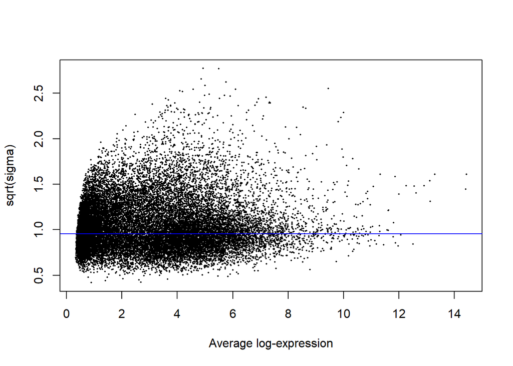

```r
vfit <- lmFit(v, design)
vfit <- contrasts.fit(vfit, contrasts=cont.matrix)
efit <- eBayes(vfit)
plotSA(efit)
```

```r
##Examining the number of DE genes
summary(decideTests(efit))
```

```
##        postvspre
## Down           0
## NotSig     22648
## Up             0
```

```r
res3<-topTable(efit, adjust="BH",number=nrow(y), sort.by = "P")
topTable(efit, adjust="BH", sort.by = "P")
```

```
##                   logFC  AveExpr         t      P.Value adj.P.Val
## AREG           1.821181 1.302251  4.871070 0.0002821774 0.9999248
## AREGB          1.566349 1.246226  4.526258 0.0005317320 0.9999248
## RP11-939C17.2  1.227131 8.951807  4.346384 0.0007441451 0.9999248
## KLHDC8A        2.275912 1.633678  4.274816 0.0008514525 0.9999248
## AGPAT4         1.495975 2.436936  4.110029 0.0011633920 0.9999248
## SEMA7A         1.389598 4.163390  4.034294 0.0013440260 0.9999248
## REV3L         -1.128981 3.544674 -4.028760 0.0013583020 0.9999248
## P2RX7         -1.903131 3.797251 -4.004246 0.0014234355 0.9999248
## APCDD1L        1.383108 1.323862  3.987716 0.0014691529 0.9999248
## ALCAM          1.722689 4.103423  3.975071 0.0015051389 0.9999248
##                       B
## AREG          -4.174998
## AREGB         -4.206921
## RP11-939C17.2 -4.226920
## KLHDC8A       -4.212048
## AGPAT4        -4.340353
## SEMA7A        -4.277438
## REV3L         -4.311287
## P2RX7         -4.306439
## APCDD1L       -4.269699
## ALCAM         -4.291010
```

```r
tfit <- treat(vfit, lfc=1)
dt <- decideTests(tfit)
summary(dt)
```

```
##        postvspre
## Down           0
## NotSig     22648
## Up             0
```

```r
res4<-topTreat(tfit, coef=1, n=Inf)

library(Glimma)
glXYPlot(x=efit$coefficients[,1], y=efit$lods[,1],
         xlab="logFC", ylab="B", main="Top 100 DE genes",
         counts=y$counts, groups=group, status=dt, side.main="ENTREZID", folder="volcano")
```

# 10. Gen Set Enrichment Analysis (GSEA)

```r
source("https://bioconductor.org/biocLite.R")
```

```
## Bioconductor version 3.7 (BiocInstaller 1.30.0), ?biocLite for help
```

```r
library(CAMERA)
load(url("http://bioinf.wehi.edu.au/software/MSigDB/human_c6_v5p2.rdata"))##ONCOGENIC
load(url("http://bioinf.wehi.edu.au/software/MSigDB/human_c2_v5p2.rdata"))##CURATOR
load(url("http://bioinf.wehi.edu.au/software/MSigDB/human_c7_v5p2.rdata"))###Inmunogenic
library(org.Hs.eg.db)
library(AnnotationDbi)

ann <- AnnotationDbi::select(org.Hs.eg.db,keys=rownames(v),columns=c("ENTREZID","SYMBOL","GENENAME"), keytype = "SYMBOL")
idx1 <- ids2indices(Hs.c2,id=ann$ENTREZID)
idx2 <- ids2indices(Hs.c6,id=ann$ENTREZID)
idx3 <- ids2indices(Hs.c7,id=ann$ENTREZID)
cam.upvslow_1<- camera(v,idx1,design,contrast=cont.matrix)
cam.upvslow_2 <- camera(v,idx2,design,contrast=cont.matrix)
cam.upvslow_3 <- camera(v,idx3,design,contrast=cont.matrix)
head(cam.upvslow_1,10)
```

```
##                                               NGenes Direction
## BIERIE_INFLAMMATORY_RESPONSE_TGFB1                 5        Up
## REACTOME_PACKAGING_OF_TELOMERE_ENDS               41        Up
## REACTOME_RNA_POL_I_PROMOTER_OPENING               51        Up
## REACTOME_MEIOTIC_SYNAPSIS                         61        Up
## KUUSELO_PANCREATIC_CANCER_19Q13_AMPLIFICATION     24        Up
## LIANG_SILENCED_BY_METHYLATION_2                   51        Up
## ZHENG_RESPONSE_TO_ARSENITE_UP                     17        Up
## REACTOME_TELOMERE_MAINTENANCE                     68        Up
## NIKOLSKY_BREAST_CANCER_20Q12_Q13_AMPLICON        104        Up
## REACTOME_MEIOSIS                                  94        Up
##                                                     PValue         FDR
## BIERIE_INFLAMMATORY_RESPONSE_TGFB1            1.726586e-06 0.008163298
## REACTOME_PACKAGING_OF_TELOMERE_ENDS           1.572429e-05 0.030146256
## REACTOME_RNA_POL_I_PROMOTER_OPENING           1.912834e-05 0.030146256
## REACTOME_MEIOTIC_SYNAPSIS                     4.771938e-05 0.056309259
## KUUSELO_PANCREATIC_CANCER_19Q13_AMPLIFICATION 5.954871e-05 0.056309259
## LIANG_SILENCED_BY_METHYLATION_2               1.088337e-04 0.085760954
## ZHENG_RESPONSE_TO_ARSENITE_UP                 1.471436e-04 0.099385019
## REACTOME_TELOMERE_MAINTENANCE                 3.670482e-04 0.216925481
## NIKOLSKY_BREAST_CANCER_20Q12_Q13_AMPLICON     4.857093e-04 0.255159263
## REACTOME_MEIOSIS                              7.292599e-04 0.344794060
```

```r
head(cam.upvslow_2,10)
```

```
##                               NGenes Direction      PValue       FDR
## HINATA_NFKB_MATRIX                10        Up 0.009703821 0.9715642
## ERB2_UP.V1_DN                    180      Down 0.028812718 0.9715642
## KRAS.600.LUNG.BREAST_UP.V1_UP    199        Up 0.037400544 0.9715642
## AKT_UP.V1_DN                     160        Up 0.042524217 0.9715642
## PTEN_DN.V2_UP                    112        Up 0.053210995 0.9715642
## HINATA_NFKB_IMMU_INF              16        Up 0.056125784 0.9715642
## PKCA_DN.V1_UP                    119        Up 0.062644190 0.9715642
## CAHOY_ASTROGLIAL                  84        Up 0.065156490 0.9715642
## RB_P130_DN.V1_UP                 108        Up 0.069578247 0.9715642
## MTOR_UP.N4.V1_UP                 180        Up 0.078957651 0.9715642
```

```r
head(cam.upvslow_3,10)
```

```
##                                                                 NGenes
## GSE6269_E_COLI_VS_STREP_PNEUMO_INF_PBMC_DN                         137
## GSE6269_E_COLI_VS_STAPH_AUREUS_INF_PBMC_DN                         157
## GSE22886_NAIVE_BCELL_VS_NEUTROPHIL_UP                              188
## GSE46606_IRF4_KO_VS_WT_CD40L_IL2_IL5_1DAY_STIMULATED_BCELL_DN      159
## GSE360_DC_VS_MAC_B_MALAYI_HIGH_DOSE_DN                             186
## GSE42088_UNINF_VS_LEISHMANIA_INF_DC_2H_UP                          180
## GSE360_T_GONDII_VS_M_TUBERCULOSIS_MAC_DN                           167
## GSE22886_TH1_VS_TH2_48H_ACT_UP                                     159
## GSE18281_CORTICAL_VS_MEDULLARY_THYMOCYTE_DN                        139
## GSE36888_UNTREATED_VS_IL2_TREATED_STAT5_AB_KNOCKIN_TCELL_17H_UP    155
##                                                                 Direction
## GSE6269_E_COLI_VS_STREP_PNEUMO_INF_PBMC_DN                             Up
## GSE6269_E_COLI_VS_STAPH_AUREUS_INF_PBMC_DN                             Up
## GSE22886_NAIVE_BCELL_VS_NEUTROPHIL_UP                                Down
## GSE46606_IRF4_KO_VS_WT_CD40L_IL2_IL5_1DAY_STIMULATED_BCELL_DN          Up
## GSE360_DC_VS_MAC_B_MALAYI_HIGH_DOSE_DN                                 Up
## GSE42088_UNINF_VS_LEISHMANIA_INF_DC_2H_UP                              Up
## GSE360_T_GONDII_VS_M_TUBERCULOSIS_MAC_DN                               Up
## GSE22886_TH1_VS_TH2_48H_ACT_UP                                         Up
## GSE18281_CORTICAL_VS_MEDULLARY_THYMOCYTE_DN                            Up
## GSE36888_UNTREATED_VS_IL2_TREATED_STAT5_AB_KNOCKIN_TCELL_17H_UP        Up
##                                                                      PValue
## GSE6269_E_COLI_VS_STREP_PNEUMO_INF_PBMC_DN                      0.003713143
## GSE6269_E_COLI_VS_STAPH_AUREUS_INF_PBMC_DN                      0.006261204
## GSE22886_NAIVE_BCELL_VS_NEUTROPHIL_UP                           0.006416659
## GSE46606_IRF4_KO_VS_WT_CD40L_IL2_IL5_1DAY_STIMULATED_BCELL_DN   0.008835370
## GSE360_DC_VS_MAC_B_MALAYI_HIGH_DOSE_DN                          0.009237154
## GSE42088_UNINF_VS_LEISHMANIA_INF_DC_2H_UP                       0.017068509
## GSE360_T_GONDII_VS_M_TUBERCULOSIS_MAC_DN                        0.018599815
## GSE22886_TH1_VS_TH2_48H_ACT_UP                                  0.020530863
## GSE18281_CORTICAL_VS_MEDULLARY_THYMOCYTE_DN                     0.020654489
## GSE36888_UNTREATED_VS_IL2_TREATED_STAT5_AB_KNOCKIN_TCELL_17H_UP 0.022275380
##                                                                       FDR
## GSE6269_E_COLI_VS_STREP_PNEUMO_INF_PBMC_DN                      0.9999498
## GSE6269_E_COLI_VS_STAPH_AUREUS_INF_PBMC_DN                      0.9999498
## GSE22886_NAIVE_BCELL_VS_NEUTROPHIL_UP                           0.9999498
## GSE46606_IRF4_KO_VS_WT_CD40L_IL2_IL5_1DAY_STIMULATED_BCELL_DN   0.9999498
## GSE360_DC_VS_MAC_B_MALAYI_HIGH_DOSE_DN                          0.9999498
## GSE42088_UNINF_VS_LEISHMANIA_INF_DC_2H_UP                       0.9999498
## GSE360_T_GONDII_VS_M_TUBERCULOSIS_MAC_DN                        0.9999498
## GSE22886_TH1_VS_TH2_48H_ACT_UP                                  0.9999498
## GSE18281_CORTICAL_VS_MEDULLARY_THYMOCYTE_DN                     0.9999498
## GSE36888_UNTREATED_VS_IL2_TREATED_STAT5_AB_KNOCKIN_TCELL_17H_UP 0.9999498
```